# Gender Inequality and HIV/AIDS in Sub-saharan Africa

Mufaro Chinake

21/04/2022

# 1.1 Introduction

The dataset was obtained from https://data.world/makeovermonday/2021w2. The dataset was published by Visualize Gender Equality (viz5)- an initiative to help the United Nations Development Goal 5: achieve gender equality and empower all women and girls. The source of the data published in the dataset is UNICEF.

The dataset consists of 2640 observations over 10 variables. The data was collected from 1990 to 2019 for adolescents of ages between 10 and 19 years from different African countries. The following information for each country,gender and year is also featured in the dataset: estimated incidence rate of new HIV infections per 1000 uninfected population, estimated number of annual AIDS related deaths, estimated number of people living with HIV and the estimated rate of annual AIDS related deaths per 100 000 people.

# 1.2 Explanatory Data Analysis using R programming language and Tableau

## 1.2.1 Data cleaning

### Displaying of the first four lines of the dataset:

```r
HIV_data = read.csv("~/GitHub/HIV-AIDS in Africa/Jan 2021 Data - Viz5 Gender Inequality and HIVAIDS.csv")
head(HIV_data,4)
```

```
##   Country               UNICEF.Region Year    Sex       Age
## 1  Angola Eastern and Southern Africa 1990 Female Age 10-19
## 2  Angola Eastern and Southern Africa 1990   Male Age 10-19
## 3  Angola Eastern and Southern Africa 1991 Female Age 10-19
## 4  Angola Eastern and Southern Africa 1991   Male Age 10-19
##   Estimated.incidence.rate.of.new.HIV.infection.per.1.000.uninfected.population
## 1                                                                          0.64
## 2                                                                          0.15
## 3                                                                          0.75
## 4                                                                          0.17
##   Estimated.number.of.annual.AIDS.related.deaths
## 1                                            100
## 2                                            100
## 3                                            100
## 4                                            100
##   Estimated.number.of.annual.new.HIV.infections
## 1                                           500
## 2                                           100
## 3                                           500
## 4                                           200
##   Estimated.number.of.people.living.with.HIV
## 1                                        860
## 2                                        200
## 3                                       1100
## 4                                        500
##   Estimated.rate.of.annual.AIDS.related.deaths..per.100.000.population
## 1                                                                 0.36
## 2                                                                 0.07
## 3                                                                 0.42
## 4                                                                 0.14
```

Display of the last four lines of the dataset:

```r
tail(HIV_data,4)
```

```
##       Country               UNICEF.Region Year    Sex       Age
## 2637 Zimbabwe Eastern and Southern Africa 2018 Female Age 10-19
## 2638 Zimbabwe Eastern and Southern Africa 2018   Male Age 10-19
## 2639 Zimbabwe Eastern and Southern Africa 2019 Female Age 10-19
## 2640 Zimbabwe Eastern and Southern Africa 2019   Male Age 10-19
##      Estimated.incidence.rate.of.new.HIV.infection.per.1.000.uninfected.population
## 2637                                                                          6.05
## 2638                                                                          1.46
## 2639                                                                          5.99
## 2640                                                                          1.43
##      Estimated.number.of.annual.AIDS.related.deaths
## 2637                                            770
## 2638                                            800
## 2639                                            690
## 2640                                            730
##      Estimated.number.of.annual.new.HIV.infections
## 2637                                          4400
## 2638                                          1100
## 2639                                          4400
## 2640                                          1100
##      Estimated.number.of.people.living.with.HIV
## 2637                                      48000
## 2638                                      37000
## 2639                                      48000
## 2640                                      37000
##      Estimated.rate.of.annual.AIDS.related.deaths..per.100.000.population
## 2637                                                                48.39
## 2638                                                                49.97
## 2639                                                                42.18
## 2640                                                                44.57
```

Displaying column names:

```r
colnames(HIV_data)
```

```
##  [1] "Country"
##  [2] "UNICEF.Region"
##  [3] "Year"
##  [4] "Sex"
##  [5] "Age"
##  [6] "Estimated.incidence.rate.of.new.HIV.infection.per.1.000.uninfected.population"
##  [7] "Estimated.number.of.annual.AIDS.related.deaths"
##  [8] "Estimated.number.of.annual.new.HIV.infections"
##  [9] "Estimated.number.of.people.living.with.HIV"
## [10] "Estimated.rate.of.annual.AIDS.related.deaths..per.100.000.population"
```

Some of the column names are incompatible with R programming language and were corrected as shown below:

```r
library(dplyr)
HIV_data = rename(HIV_data,Estimated_incidence_rate_of_new_HIV_infections_per1000_uninfected_populaton =Estimated.incidence.rate.of.new.HIV.infection.per.1.000.uninfected.population,
                   Estimated_number_of_annual_AIDS_related_deaths = Estimated.number.of.annual.AIDS.related.deaths,
                   Estimated_number_of_annual_new_HIV_infections = Estimated.number.of.annual.new.HIV.infections,
                   Estimated_number_of_people_living_with_HIV = Estimated.number.of.people.living.with.HIV,
                   Estimated_rate_of_annual_AIDS_related_deaths_per_100000_population = Estimated.rate.of.annual.AIDS.related.deaths..per.100.000.population)
```

### Checking for missing information

The dataset was checked for missing information and the rows missing information were stored in a dataset called “incomplete_HIV” to observe the fields with missing data. 180 rows of the data had missing information. The summary of the dataset created is displayed below.Estimated incidence rate of new HIV infection per 1 000 uninfected population recorded 120 NA values,Estimated number of annual AIDS related deaths recorded 60 NA values,Estimated number of annual new HIV infections recorded 120 NA values, and Estimated rate of annual AIDS related deaths per 100 000 population recorded 60 NA values.

```r
x = which(!complete.cases(HIV_data))

incomplete_HIV = HIV_data[x,]
summary(incomplete_HIV)
```

```
##    Country          UNICEF.Region           Year          Sex
##  Length:180         Length:180         Min.   :1990   Length:180
##  Class :character   Class :character   1st Qu.:1997   Class :character
##  Mode  :character   Mode  :character   Median :2004   Mode  :character
##                                        Mean   :2004
##                                        3rd Qu.:2012
##                                        Max.   :2019
##
##      Age
##  Length:180
##  Class :character
##  Mode  :character
##
##
##
##
##  Estimated_incidence_rate_of_new_HIV_infections_per1000_uninfected_populaton
##  Min.   :0.0100
##  1st Qu.:0.1250
##  Median :0.2700
##  Mean   :0.2800
##  3rd Qu.:0.4325
##  Max.   :0.5600
##  NA's   :120
##  Estimated_number_of_annual_AIDS_related_deaths
##  Min.   :100.0
##  1st Qu.:100.0
##  Median :100.0
##  Mean   :150.8
##  3rd Qu.:200.0
##  Max.   :500.0
##  NA's   :60
##  Estimated_number_of_annual_new_HIV_infections
##  Min.   :100
##  1st Qu.:100
##  Median :100
##  Mean   :100
##  3rd Qu.:100
##  Max.   :100
##  NA's   :120
##  Estimated_number_of_people_living_with_HIV
##  Min.   : 100
##  1st Qu.: 100
##  Median : 100
##  Mean   :1466
##  3rd Qu.:2975
##  Max.   :7300
##
##  Estimated_rate_of_annual_AIDS_related_deaths_per_100000_population
##  Min.   : 0.0100
##  1st Qu.: 0.6475
##  Median : 1.9650
##  Mean   : 4.2681
##  3rd Qu.: 8.8475
##  Max.   :12.5200
##  NA's   :60
```

### Treating NA Values:

All the NA values for each variable will be replaced by the median because removing rows with NA values may leave leave countries with no data for some years and also outliers have little effect on the median.

Replacing NA Values from the column “Estimated incidence rate of new HIV infection per 1 000 uninfected population” with the median- 1.15 (the median is calculated below)

```r
summary(HIV_data$Estimated_incidence_rate_of_new_HIV_infections_per1000_uninfected_populaton)
```

```
##    Min. 1st Qu.  Median    Mean 3rd Qu.    Max.    NA's
##   0.010   0.320   1.150   3.751   3.500  70.630     120
```

```r
HIV_data$Estimated_incidence_rate_of_new_HIV_infections_per1000_uninfected_populaton[which(is.na(HIV_data$Estimated_incidence_rate_of_new_HIV_infections_per1000_uninfected_populaton))] = 1.15


which(!complete.cases(HIV_data$Estimated_incidence_rate_of_new_HIV_infections_per1000_uninfected_populaton))
```

```
## integer(0)
```

Replacing NA values in the column “Estimated number of annual AIDS related deaths” with the median- 100 calculated below

```r
summary(HIV_data$Estimated_number_of_annual_AIDS_related_deaths)
```

```
##    Min. 1st Qu.  Median    Mean 3rd Qu.    Max.    NA's
##   100.0   100.0   100.0   391.9   500.0  3500.0      60
```

```r
HIV_data$Estimated_number_of_annual_AIDS_related_deaths[which(is.na(HIV_data$Estimated_number_of_annual_AIDS_related_deaths))] = 100


which(!complete.cases(HIV_data$Estimated_number_of_annual_AIDS_related_deaths))
```

```
## integer(0)
```

Replacing NA values from the column “Estimated number of annual new HIV infections” with the median-500 calculated below

```r
summary(HIV_data$Estimated_number_of_annual_new_HIV_infections)
```

```
##    Min. 1st Qu.  Median    Mean 3rd Qu.    Max.    NA's
##     100     100     500    2777    2100   90000     120
```

```r
HIV_data$Estimated_number_of_annual_new_HIV_infections[which(is.na(HIV_data$Estimated_number_of_annual_new_HIV_infections))] = 500


which(!complete.cases(HIV_data$Estimated_number_of_annual_new_HIV_infections))
```

```
## integer(0)
```

Replacing NA values in the column “Estimated rate of annual AIDS related deaths per 100 000 population” with the median- 9.00 calculated below

```r
summary(HIV_data$Estimated_rate_of_annual_AIDS_related_deaths_per_100000_population)
```

```
##    Min. 1st Qu.  Median    Mean 3rd Qu.    Max.    NA's
##    0.01    2.29    9.00   16.71   21.40  138.24      60
```

```r
HIV_data$Estimated_rate_of_annual_AIDS_related_deaths_per_100000_population[which(is.na(HIV_data$Estimated_rate_of_annual_AIDS_related_deaths_per_100000_population))] = 9


which(!complete.cases(HIV_data$Estimated_rate_of_annual_AIDS_related_deaths_per_100000_population))
```

```
## integer(0)
```

To check if the dataset still contains NA values after replacing all the empty fields with their respective median.

```r
which(!complete.cases(HIV_data))
```

```
## integer(0)
```

The syntax above returns an integer of zero to show that all the NA values have been replaced by the respective median.

### Box plots for quantitative variables were ploted to check for outliers:

i Estimated incidence rate of new HIV infection per 1 000 uninfected population

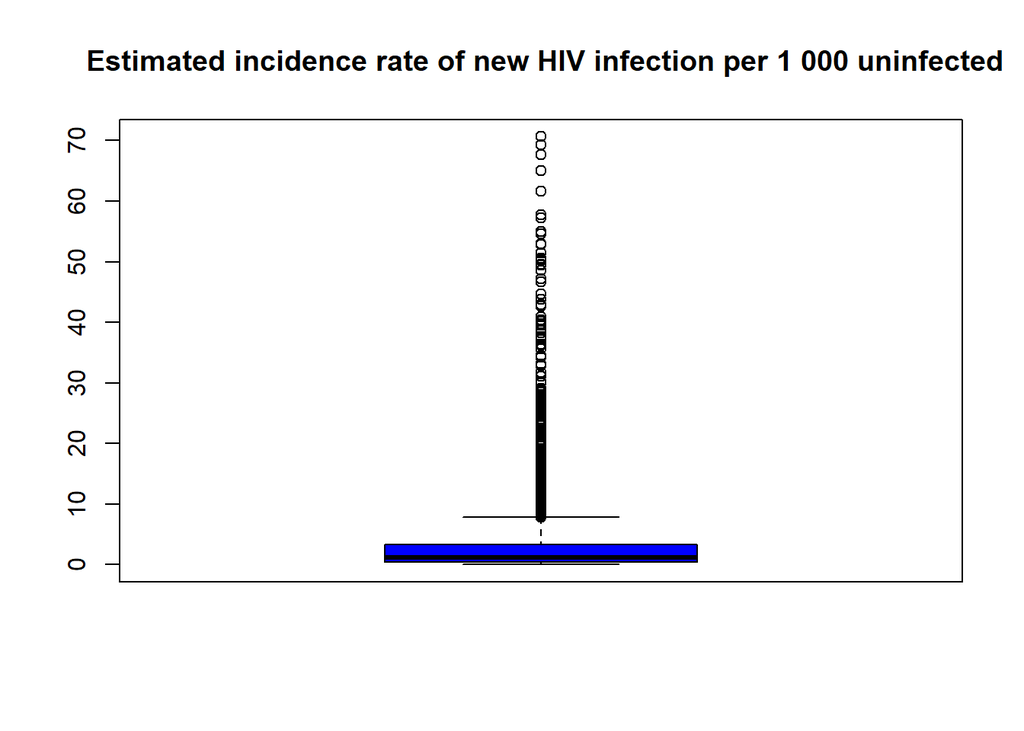

```r
boxplot(HIV_data$Estimated_incidence_rate_of_new_HIV_infections_per1000_uninfected_populaton,
        main = " Estimated incidence rate of new HIV infection per 1 000 uninfected",
        col = "blue")
```

The boxplot above shows that the column ” Estimated incidence rate of new HIV infection per 1 000 uninfected population” contains observations which are outliers.

2. Estimated number of annual AIDS related deaths:

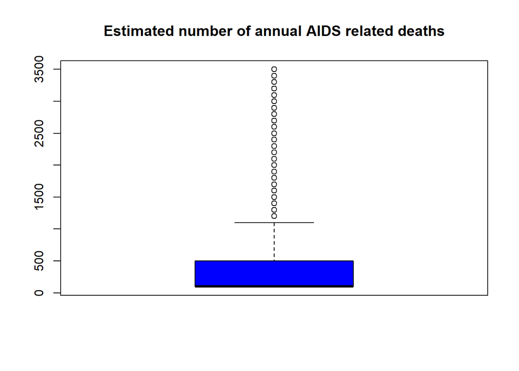

```r
boxplot(HIV_data$Estimated_number_of_annual_AIDS_related_deaths,
        main = "Estimated number of annual AIDS related deaths",
        col = "blue")
```

The boxplot above shows that the column “Estimated number of annual AIDS related deaths” contains observations which are outliers.

3. Estimated number of annual new HIV infections

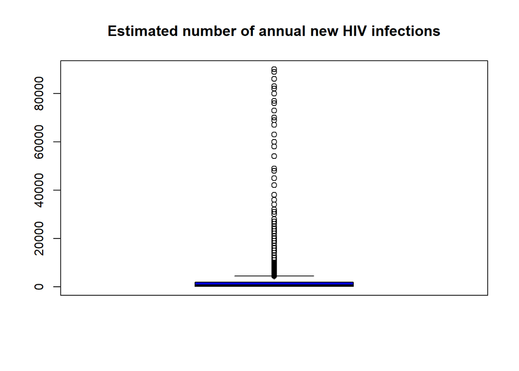

```r
boxplot(HIV_data$Estimated_number_of_annual_new_HIV_infections,
        main = "Estimated number of annual new HIV infections",
        col = "blue")
```

The boxplot above shows that the column “Estimated number of annual new HIV infections” contains observations which are outliers.

4. Estimated number of people living with HIV

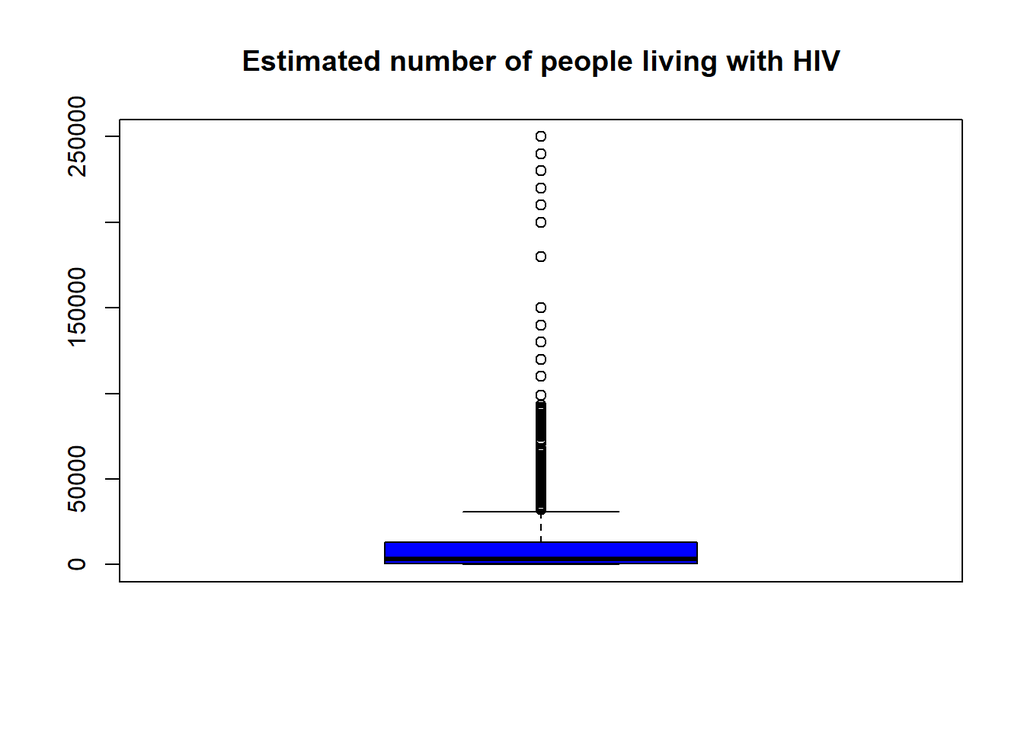

```r
boxplot(HIV_data$Estimated_number_of_people_living_with_HIV,
        main = "Estimated number of people living with HIV",
        col = "blue")
```

The boxplot above shows that the column “Estimated number of people living with HIV” contains observations which are outliers.

22. Estimated rate of annual AIDS related deaths per 100 000 population

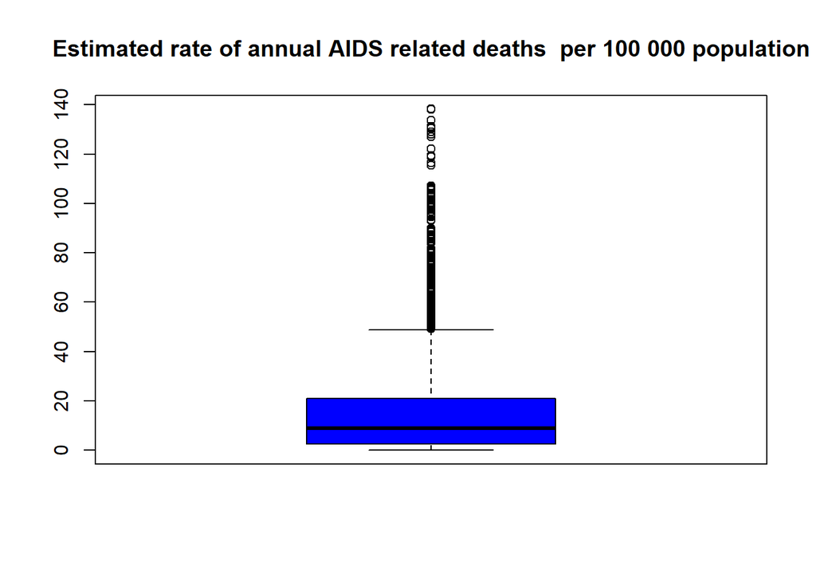

```r
boxplot(HIV_data$Estimated_rate_of_annual_AIDS_related_deaths_per_100000_population,
        main = "Estimated rate of annual AIDS related deaths  per 100 000 population",
        col = "blue")
```

```r
summary(HIV_data)
```

```
##    Country          UNICEF.Region           Year          Sex
##  Length:2640        Length:2640        Min.   :1990   Length:2640
##  Class :character   Class :character   1st Qu.:1997   Class :character
##  Mode  :character   Mode  :character   Median :2004   Mode  :character
##                                        Mean   :2004
##                                        3rd Qu.:2012
##                                        Max.   :2019
##      Age
##  Length:2640
##  Class :character
##  Mode  :character
##
##
##
##  Estimated_incidence_rate_of_new_HIV_infections_per1000_uninfected_populaton
##  Min.   : 0.010
##  1st Qu.: 0.350
##  Median : 1.150
##  Mean   : 3.633
##  3rd Qu.: 3.360
##  Max.   :70.630
##  Estimated_number_of_annual_AIDS_related_deaths
##  Min.   : 100.0
##  1st Qu.: 100.0
##  Median : 100.0
##  Mean   : 385.3
##  3rd Qu.: 500.0
##  Max.   :3500.0
##  Estimated_number_of_annual_new_HIV_infections
##  Min.   :  100
##  1st Qu.:  200
##  Median :  500
##  Mean   : 2674
##  3rd Qu.: 1900
##  Max.   :90000
##  Estimated_number_of_people_living_with_HIV
##  Min.   :   100
##  1st Qu.:   630
##  Median :  3300
##  Mean   : 13024
##  3rd Qu.: 13000
##  Max.   :250000
##  Estimated_rate_of_annual_AIDS_related_deaths_per_100000_population
##  Min.   :  0.010
##  1st Qu.:  2.408
##  Median :  9.000
##  Mean   : 16.534
##  3rd Qu.: 21.075
##  Max.   :138.240
```

NB:Outliers for each variable will not be removed or deleted because all the maximum values are realistic. Removing or replacing outliers may lead to loss of valuable information.

## 1.2.2 Data visualization

The clean dataset was exported to a csv file. Futher analysis and data visualization was carried out using tableau in the link provided below.

```r
write.table(HIV_data,"HIV_clean.csv",sep = ",",row.names = F)
```

https://public.tableau.com/app/profile/mufaro.chinake/viz/GenderinequalityinHIVAIDSinfectionsinAdolescentsinAfrica/Introduction

# 1.3 Conclusion